# Figures: 2008-2015 averages by county

asmtry

# Setup

This worksheet leans heavily on `tidyverse` packages.

## Import data

`cdl.table` contains relations between crops, their index number in the Cropland Data Layer, and the corresponding name and index number in the FAO Indicative Crop Classification (ICC 1.1).

`roi.table` contains relations from the regions of interest used to aggregrate the WF, PPT, and CWU calculations performed in steps 8-10. Here, the relation is the attribute table from a shapefile of California county political boundaries. Attributes include: county index, name, and corresponding DWR hydrologic region.

`ca.counties` contains the shapefile, on which `roi.table` is based.

`ca.hr` contains the shapefile of DWR hydrologic regions, for California.

`wf.master.wyear` contains annual sums of cwr, ppt, etc, wf, and harvested tons/acres/USD aggregrated by crop, county, and water year. It only includes the counties that have corresponding entries in the County Ag Comissioners (CAC) annual yield reports. Counties that had modeled ag production, without an accompanying entry in the CAC annual reports were omitted.

`wf.master.cyear` contains the above, except aggregrated by calendar year (instead of water year). This data set includes the extra year of 2007.

`yield.master` contains all of the statistics reported by the CAC annual reports (production tons, harvested acres, value in USD), for the modeled crops.

## Create some functions for commonly used summary statistics

Typially in a boxplot, outliers are marked as values that fall outside of 1.5 times the interquartile range avove and below the 25% and 75% quantiles. `is_extreme()` is a function that we define below, that applys the same criteria and returns TRUE if the value is a suspected outlier/extreme falue, and false otherwise.

```r
is_extreme <- function(series) {
  #' Tags values in a series according to whether or not they would appear as oulier points
  #` in a Tukey boxplot (values that lie outside of the H-spread.)
  #` Specifically, these are values that are less or greater than the 1st and 3rd quartiles
  #` plus 1.5 times the interquartile range.
  #' @param series Vector of type numeric (int or double)
  #' @return Vector of type logical, TRUE if the value is an outlier, FALSE if it is not
  return(series < (quantile(series, 0.25) - (1.5 * IQR(series)) ) | series > (quantile(series, 0.75) + (1.5 * IQR(series)) ))
}
```

## Clean erronious observations

Here, we clean obviously erronious observations.

I think the 2009 Riverside CAC survey severly under-reports the “Oats” category to the point that it makes the “Oats” water footprint blow up (several orders of magnitude higher than baseline, see the by-year summary notebook).

```r
wf.master.wyear <- wf.master.wyear %>%
  filter(!(`cdl.name` == "Oats" & `County` == "Riverside" & `Year` == 2009))
```

# C1: Average statewide water demand *for all* years, by county

Here, we sum all daily volumes of cwr, ppt, et, and wf by county, over each calendar and water year. Then, we average all of the yearly sums, to produce an “average year” value, for each parameter.

```r
wf.master.allcounty.cyear <- wf.master.cyear %>%
  group_by(roi.index, County, Year) %>%
  summarize_at(vars(cwr, ppt, et.b, et.g, wf.b, wf.g), funs(sum(., na.rm = TRUE))) %>%
  group_by(roi.index, County) %>%
  summarize_at(vars(cwr, ppt, et.b, et.g, wf.b, wf.g), funs(avg = "mean")) %>%
  left_join(roi.table %>% select(NUM,`HR_NAME`),
            by = c("roi.index" = "NUM")) %>%
  ungroup() %>%         # I'm not sure what to think about the expicit `ungroup()`
  `attr<-`("year_type", "calendar") %>%
  `attr<-`("summary_type", "total")

wf.master.allcounty.wyear <- wf.master.wyear %>%
  group_by(roi.index, County, Year) %>%
  summarize_at(vars(cwr, ppt, et.b, et.g, wf.b, wf.g), funs(sum(., na.rm = TRUE))) %>%
  group_by(roi.index, County) %>%
  summarize_at(vars(cwr, ppt, et.b, et.g, wf.b, wf.g), funs(avg = "mean")) %>%
  left_join(roi.table %>% select(NUM,`HR_NAME`),
            by = c("roi.index" = "NUM")) %>%
  ungroup() %>%
  `attr<-`("year_type", "water") %>%
  `attr<-`("summary_type", "total")
```

# C2: Join spatial indicies

We have imported the spatial layers as simple features, implemented within tidy dataframes. Thus, we can join other attributes to each spatial feature, provided that the indicies align. Here, we are joining the county-wise average annual statistics, also visualized in notebook 2, `2.cuml_avg_cnty.Rmd`.

For California counties, we join the average yearly totals (from WY 08-15) to each county polygon.

For DWR Hydrologic Regions, we total the average wf/cwu/ppt of all of the counties that lie within a particular hydrological region. The relation between counties -> hydrologic regions was done earlier with a spatial join based on county centroids in GDAL+QGIS. That is, a county was classed into a particular hydrological region depending on which region its *centroid* resided.

```r
ca.counties.allwy <- ca.counties %>%
  left_join(wf.master.allcounty.wyear %>%
              select(roi.index, cwr_avg, ppt_avg, et.b_avg, et.g_avg, wf.b_avg, wf.g_avg),
            by = c("NUM" = "roi.index"))


ca.hr.allwy <- ca.hr %>%
  left_join(wf.master.allcounty.wyear %>%
              group_by(`HR_NAME`) %>%
              summarize_at(vars(cwr_avg, ppt_avg, et.b_avg, et.g_avg, wf.b_avg, wf.g_avg), funs(sum(., na.rm = TRUE))),
            by = c("HR_NAME" = "HR_NAME"))
```

# P1: County-wise averages, WF Blue/Green, CWU, and PPT

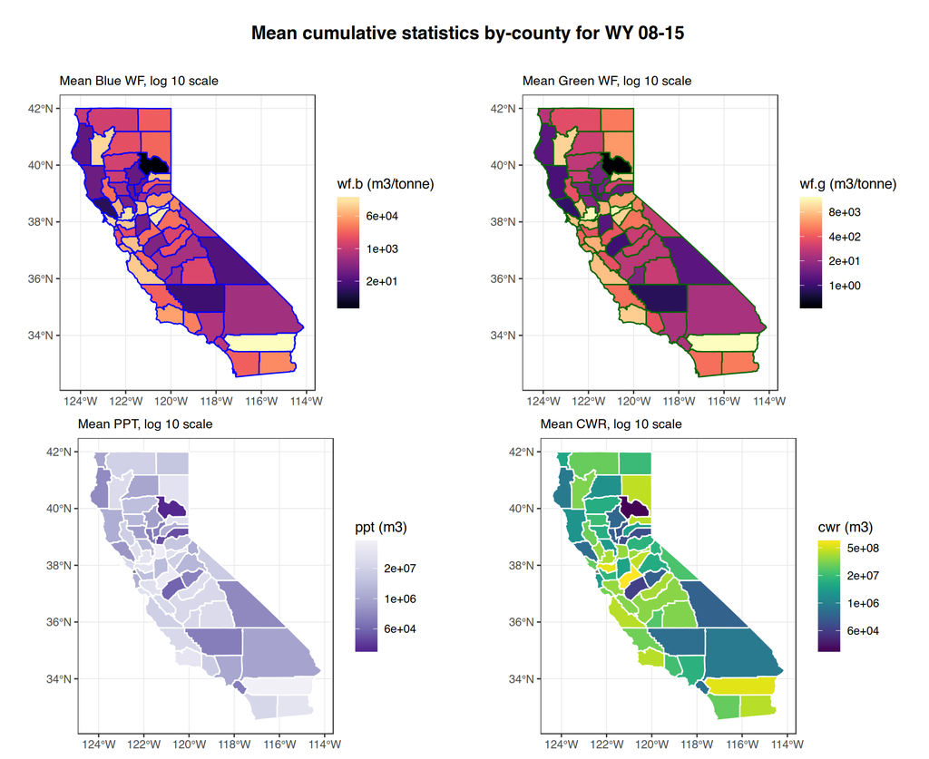

```r
local({
  cty.wfb <- ca.counties.allwy %>%
    ggplot() +
    geom_sf(mapping = aes(fill = wf.b_avg), color = "blue") +
    scale_fill_viridis(name = "wf.b (m3/tonne)", trans = "log", option = "magma",
                       labels = function(x) format(signif(x,1)/1, scientific = TRUE)) +
     labs(subtitle = "Mean Blue WF, log 10 scale")

  cty.wfg <- ca.counties.allwy %>%
    ggplot() +
    geom_sf(mapping = aes(fill = wf.g_avg), color = "darkgreen") +
    scale_fill_viridis(name = "wf.g (m3/tonne)", trans = "log", option = "magma",
                       labels = function(x) format(signif(x,1)/1, scientific = TRUE)) +
     labs(subtitle = "Mean Green WF, log 10 scale")

  cty.ppt <- ca.counties.allwy %>%
    ggplot() +
    geom_sf(mapping = aes(fill = ppt_avg), color = "white") +
    scale_fill_distiller(name = "ppt (m3)", trans = "log", type = "seq", palette = "Purples",
                       labels = function(x) format(signif(x,1)/1, scientific = TRUE)) +
     labs(subtitle = "Mean PPT, log 10 scale")

  cty.cwr <- ca.counties.allwy %>%
    ggplot() +
    geom_sf(mapping = aes(fill = cwr_avg), color = "white") +
    scale_fill_viridis(name = "cwr (m3)", trans = "log", option = "viridis",
                       labels = function(x) format(signif(x,1)/1, scientific = TRUE)) +
     labs(subtitle = "Mean CWR, log 10 scale")

  t1 <- ggdraw() + draw_label("Mean cumulative statistics by-county for WY 08-15",
                              fontface='bold')
  plot_grid(t1, arrangeGrob(cty.wfb, cty.wfg, cty.ppt, cty.cwr),
            ncol = 1, rel_heights = c(0.1, 1))
})
```

# P2: HR-wise averages, WF Blue/Green, CWU, and PPT

Where HR stands for Hydrologic Region. Tallies within each regon represent the sum of all of the counties whose centroids lie within each region.

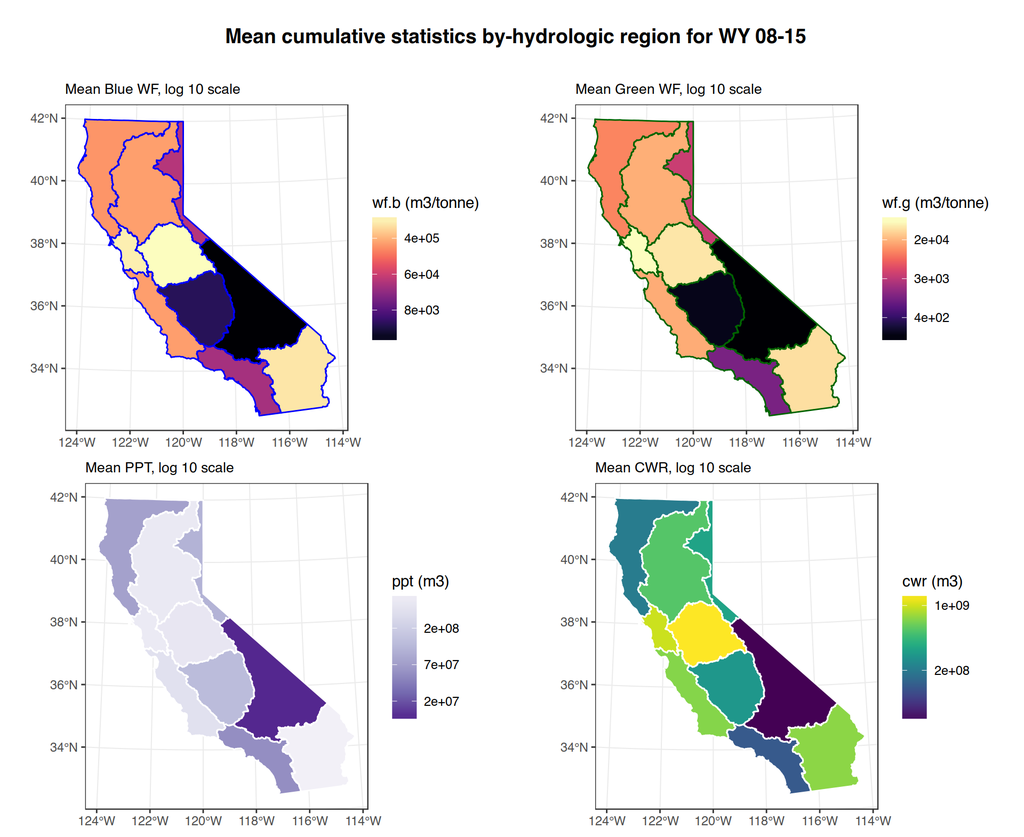

```r
local({
  hr.wfb <- ca.hr.allwy %>%
    ggplot() +
    geom_sf(mapping = aes(fill = wf.b_avg), color = "blue") +
    scale_fill_viridis(name = "wf.b (m3/tonne)", trans = "log", option = "magma",
                       labels = function(x) format(signif(x,1)/1, scientific = TRUE)) +
     labs(subtitle = "Mean Blue WF, log 10 scale")

  hr.wfg <- ca.hr.allwy %>%
    ggplot() +
    geom_sf(mapping = aes(fill = wf.g_avg), color = "darkgreen") +
    scale_fill_viridis(name = "wf.g (m3/tonne)", trans = "log", option = "magma",
                       labels = function(x) format(signif(x,1)/1, scientific = TRUE)) +
     labs(subtitle = "Mean Green WF, log 10 scale")

  hr.ppt <- ca.hr.allwy %>%
    ggplot() +
    geom_sf(mapping = aes(fill = ppt_avg), color = "white") +
    scale_fill_distiller(name = "ppt (m3)", trans = "log", type = "seq", palette = "Purples",
                       labels = function(x) format(signif(x,1)/1, scientific = TRUE)) +
     labs(subtitle = "Mean PPT, log 10 scale")

  hr.cwr <- ca.hr.allwy %>%
    ggplot() +
    geom_sf(mapping = aes(fill = cwr_avg), color = "white") +
    scale_fill_viridis(name = "cwr (m3)", trans = "log", option = "viridis",
                       labels = function(x) format(signif(x,1)/1, scientific = TRUE)) +
     labs(subtitle = "Mean CWR, log 10 scale")

  t1 <- ggdraw() + draw_label("Mean cumulative statistics by-hydrologic region for WY 08-15",
                              fontface='bold')
  plot_grid(t1, arrangeGrob(hr.wfb, hr.wfg, hr.ppt, hr.cwr, ncol = 2, nrow = 2),
            ncol = 1, rel_heights = c(0.1, 1))
})
```

# Chunks not run

## Playing around with new geatures in st/ggplot2